# Risk Factor Analysis

## Outcome Variable

**Outcome Variable:** ever_stunted

## Predictor Variables

**Intervention Variable:** nhh

**Adjustment Set:**

unadjusted

## Stratifying Variables

The analysis was stratified on these variable(s):

- agecat
- studyid

The following strata were considered:

- agecat: 12 months, studyid: ki1000108-IRC
- agecat: 12 months, studyid: ki1000304b-SAS-FoodSuppl
- agecat: 12 months, studyid: ki1017093-NIH-Birth
- agecat: 12 months, studyid: ki1017093b-PROVIDE
- agecat: 12 months, studyid: ki1017093c-NIH-Crypto
- agecat: 12 months, studyid: ki1148112-LCNI-5
- agecat: 18 months, studyid: ki1000108-IRC
- agecat: 18 months, studyid: ki1000304b-SAS-FoodSuppl
- agecat: 18 months, studyid: ki1017093-NIH-Birth
- agecat: 18 months, studyid: ki1017093b-PROVIDE
- agecat: 18 months, studyid: ki1017093c-NIH-Crypto
- agecat: 18 months, studyid: ki1148112-LCNI-5
- agecat: 24 months, studyid: ki1000108-IRC
- agecat: 24 months, studyid: ki1000304b-SAS-FoodSuppl
- agecat: 24 months, studyid: ki1017093-NIH-Birth
- agecat: 24 months, studyid: ki1017093b-PROVIDE
- agecat: 24 months, studyid: ki1017093c-NIH-Crypto
- agecat: 24 months, studyid: ki1148112-LCNI-5
- agecat: 3 months, studyid: ki1000108-IRC
- agecat: 3 months, studyid: ki1017093-NIH-Birth
- agecat: 3 months, studyid: ki1017093b-PROVIDE
- agecat: 3 months, studyid: ki1017093c-NIH-Crypto
- agecat: 6 months, studyid: ki1000108-IRC
- agecat: 6 months, studyid: ki1000304b-SAS-FoodSuppl
- agecat: 6 months, studyid: ki1017093-NIH-Birth
- agecat: 6 months, studyid: ki1017093b-PROVIDE
- agecat: 6 months, studyid: ki1017093c-NIH-Crypto
- agecat: 6 months, studyid: ki1148112-LCNI-5

### Dropped Strata

Some strata were dropped due to rare outcomes:

- agecat: 3 months, studyid: ki1017093b-PROVIDE
- agecat: 6 months, studyid: ki1000304b-SAS-FoodSuppl
- agecat: 6 months, studyid: ki1148112-LCNI-5
- agecat: 12 months, studyid: ki1000304b-SAS-FoodSuppl
- agecat: 18 months, studyid: ki1000304b-SAS-FoodSuppl
- agecat: 24 months, studyid: ki1000304b-SAS-FoodSuppl

## Methods Detail

We’re interested in the causal parameters $E[Y_a]$ for all values of $a \in \mathcal{A}$. These parameters represent the mean outcome if, possibly contrary to fact, we intervened to set all units to have $A=a$. Under the randomization and positivity assumptions, these are identified by the statistical parameters $\psi_a=E_W[E_{Y|A,W}(Y|A=a,W)]$. In addition, we’re interested in the mean of $Y$, $E[Y]$ under no intervention (the observed mean). We will estimate these parameters by using SuperLearner to fit the relevant likelihood factors – $E_{Y|A,W}(Y|A=a,W)$ and $p(A=a|W)$, and then updating our likelihood fit using a joint TMLE.

For unadjusted analyses ($W=\{\}$), initial likelihoods were estimated using Lrnr_glm to estimate the simple $E(Y|A)$ and Lrnr_mean to estimate $p(A)$. For adjusted analyses, a small library containing Lrnr_glmnet, Lrnr_xgboost, and Lrnr_mean was used.

Having estimated these parameters, we will then use the delta method to estimate relative risks and attributable risks relative to a prespecified baseline level of $A$.

# Results Detail

## Results Plots

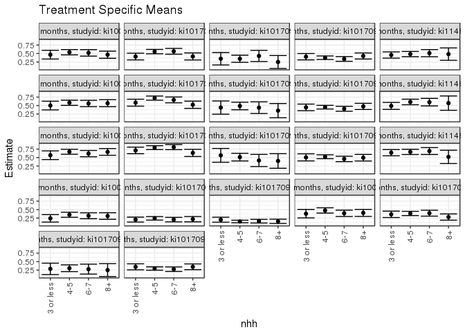

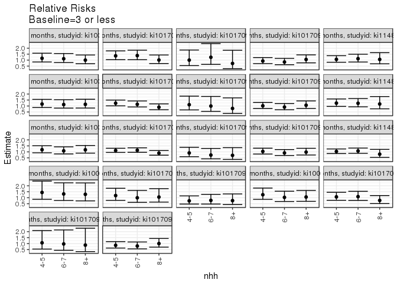

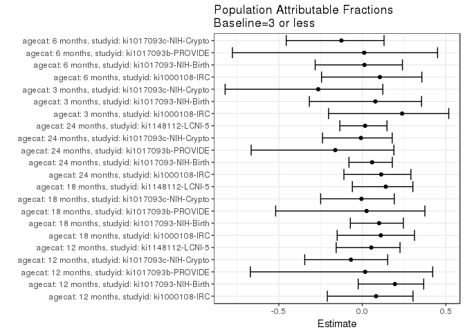

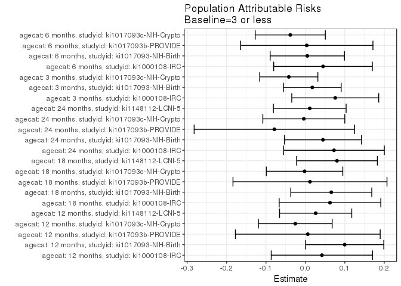

## Data Summary

| agecat | studyid | A | n | nA | nAY0 | nAY1 |
| --- | --- | --- | --- | --- | --- | --- |
| 3 months | ki1000108-IRC | 3 or less | 410 | 58 | 44 | 14 |
| 3 months | ki1000108-IRC | 4-5 | 410 | 158 | 103 | 55 |
| 3 months | ki1000108-IRC | 6-7 | 410 | 107 | 73 | 34 |
| 3 months | ki1000108-IRC | 8+ | 410 | 87 | 60 | 27 |
| 3 months | ki1000304b-SAS-FoodSuppl | 3 or less | 0 | 0 | 0 | 0 |
| 3 months | ki1000304b-SAS-FoodSuppl | 4-5 | 0 | 0 | 0 | 0 |
| 3 months | ki1000304b-SAS-FoodSuppl | 6-7 | 0 | 0 | 0 | 0 |
| 3 months | ki1000304b-SAS-FoodSuppl | 8+ | 0 | 0 | 0 | 0 |
| 3 months | ki1017093-NIH-Birth | 3 or less | 629 | 117 | 93 | 24 |
| 3 months | ki1017093-NIH-Birth | 4-5 | 629 | 264 | 200 | 64 |
| 3 months | ki1017093-NIH-Birth | 6-7 | 629 | 142 | 113 | 29 |
| 3 months | ki1017093-NIH-Birth | 8+ | 629 | 106 | 83 | 23 |
| 3 months | ki1017093b-PROVIDE | 3 or less | 175 | 32 | 24 | 8 |
| 3 months | ki1017093b-PROVIDE | 4-5 | 175 | 86 | 64 | 22 |
| 3 months | ki1017093b-PROVIDE | 6-7 | 175 | 37 | 26 | 11 |
| 3 months | ki1017093b-PROVIDE | 8+ | 175 | 20 | 17 | 3 |
| 3 months | ki1017093c-NIH-Crypto | 3 or less | 758 | 114 | 91 | 23 |
| 3 months | ki1017093c-NIH-Crypto | 4-5 | 758 | 342 | 291 | 51 |
| 3 months | ki1017093c-NIH-Crypto | 6-7 | 758 | 178 | 150 | 28 |
| 3 months | ki1017093c-NIH-Crypto | 8+ | 758 | 124 | 105 | 19 |
| 3 months | ki1148112-LCNI-5 | 3 or less | 0 | 0 | 0 | 0 |
| 3 months | ki1148112-LCNI-5 | 4-5 | 0 | 0 | 0 | 0 |
| 3 months | ki1148112-LCNI-5 | 6-7 | 0 | 0 | 0 | 0 |
| 3 months | ki1148112-LCNI-5 | 8+ | 0 | 0 | 0 | 0 |
| 6 months | ki1000108-IRC | 3 or less | 408 | 58 | 36 | 22 |
| 6 months | ki1000108-IRC | 4-5 | 408 | 158 | 83 | 75 |
| 6 months | ki1000108-IRC | 6-7 | 408 | 105 | 64 | 41 |
| 6 months | ki1000108-IRC | 8+ | 408 | 87 | 52 | 35 |
| 6 months | ki1000304b-SAS-FoodSuppl | 3 or less | 105 | 9 | 5 | 4 |
| 6 months | ki1000304b-SAS-FoodSuppl | 4-5 | 105 | 41 | 23 | 18 |

[output cut: 90 more lines]

## Results Table

### Parameter: TSM

| agecat | studyid | intervention_level | baseline_level | estimate | ci_lower | ci_upper |
| --- | --- | --- | --- | --- | --- | --- |
| 3 months | ki1000108-IRC | 3 or less | NA | 0.2413793 | 0.1311171 | 0.3516415 |
| 3 months | ki1000108-IRC | 4-5 | NA | 0.3481013 | 0.2737321 | 0.4224704 |
| 3 months | ki1000108-IRC | 6-7 | NA | 0.3177570 | 0.2294280 | 0.4060861 |
| 3 months | ki1000108-IRC | 8+ | NA | 0.3103448 | 0.2130125 | 0.4076771 |
| 3 months | ki1017093-NIH-Birth | 3 or less | NA | 0.2051282 | 0.1319028 | 0.2783536 |
| 3 months | ki1017093-NIH-Birth | 4-5 | NA | 0.2424242 | 0.1906883 | 0.2941602 |
| 3 months | ki1017093-NIH-Birth | 6-7 | NA | 0.2042254 | 0.1378664 | 0.2705843 |
| 3 months | ki1017093-NIH-Birth | 8+ | NA | 0.2169811 | 0.1384507 | 0.2955115 |
| 3 months | ki1017093c-NIH-Crypto | 3 or less | NA | 0.2017544 | 0.1280383 | 0.2754704 |
| 3 months | ki1017093c-NIH-Crypto | 4-5 | NA | 0.1491228 | 0.1113458 | 0.1868998 |
| 3 months | ki1017093c-NIH-Crypto | 6-7 | NA | 0.1573034 | 0.1037817 | 0.2108250 |
| 3 months | ki1017093c-NIH-Crypto | 8+ | NA | 0.1532258 | 0.0897843 | 0.2166673 |
| 6 months | ki1000108-IRC | 3 or less | NA | 0.3793103 | 0.2542840 | 0.5043367 |
| 6 months | ki1000108-IRC | 4-5 | NA | 0.4746835 | 0.3967248 | 0.5526423 |
| 6 months | ki1000108-IRC | 6-7 | NA | 0.3904762 | 0.2970478 | 0.4839046 |
| 6 months | ki1000108-IRC | 8+ | NA | 0.4022989 | 0.2991326 | 0.5054651 |
| 6 months | ki1017093-NIH-Birth | 3 or less | NA | 0.3600000 | 0.2658362 | 0.4541638 |
| 6 months | ki1017093-NIH-Birth | 4-5 | NA | 0.3855932 | 0.3234378 | 0.4477487 |
| 6 months | ki1017093-NIH-Birth | 6-7 | NA | 0.3934426 | 0.3066787 | 0.4802066 |
| 6 months | ki1017093-NIH-Birth | 8+ | NA | 0.2795699 | 0.1882759 | 0.3708639 |
| 6 months | ki1017093b-PROVIDE | 3 or less | NA | 0.2857143 | 0.1178791 | 0.4535495 |
| 6 months | ki1017093b-PROVIDE | 4-5 | NA | 0.3048780 | 0.2049363 | 0.4048198 |
| 6 months | ki1017093b-PROVIDE | 6-7 | NA | 0.2777778 | 0.1310227 | 0.4245328 |
| 6 months | ki1017093b-PROVIDE | 8+ | NA | 0.2500000 | 0.0596531 | 0.4403469 |
| 6 months | ki1017093c-NIH-Crypto | 3 or less | NA | 0.3454545 | 0.2565319 | 0.4343772 |
| 6 months | ki1017093c-NIH-Crypto | 4-5 | NA | 0.2960725 | 0.2468581 | 0.3452869 |
| 6 months | ki1017093c-NIH-Crypto | 6-7 | NA | 0.2758621 | 0.2094074 | 0.3423167 |
| 6 months | ki1017093c-NIH-Crypto | 8+ | NA | 0.3471074 | 0.2622278 | 0.4319871 |
| 12 months | ki1000108-IRC | 3 or less | NA | 0.4655172 | 0.3369881 | 0.5940464 |
| 12 months | ki1000108-IRC | 4-5 | NA | 0.5379747 | 0.4601412 | 0.6158081 |

[output cut: 58 more lines]

### Parameter: E(Y)

| agecat | studyid | intervention_level | baseline_level | estimate | ci_lower | ci_upper |
| --- | --- | --- | --- | --- | --- | --- |
| 3 months | ki1000108-IRC | NA | NA | 0.3170732 | 0.3137282 | 0.3204181 |
| 3 months | ki1017093-NIH-Birth | NA | NA | 0.2225755 | 0.2212135 | 0.2239375 |
| 3 months | ki1017093c-NIH-Crypto | NA | NA | 0.1596306 | 0.1583470 | 0.1609142 |
| 6 months | ki1000108-IRC | NA | NA | 0.4240196 | 0.4200514 | 0.4279878 |
| 6 months | ki1017093-NIH-Birth | NA | NA | 0.3647913 | 0.3614514 | 0.3681312 |
| 6 months | ki1017093b-PROVIDE | NA | NA | 0.2891566 | 0.2863560 | 0.2919573 |
| 6 months | ki1017093c-NIH-Crypto | NA | NA | 0.3070652 | 0.3050612 | 0.3090692 |
| 12 months | ki1000108-IRC | NA | NA | 0.5073529 | 0.5042465 | 0.5104594 |
| 12 months | ki1017093-NIH-Birth | NA | NA | 0.5101664 | 0.5042678 | 0.5160650 |
| 12 months | ki1017093b-PROVIDE | NA | NA | 0.3522013 | 0.3442175 | 0.3601850 |
| 12 months | ki1017093c-NIH-Crypto | NA | NA | 0.3799726 | 0.3778765 | 0.3820687 |
| 12 months | ki1148112-LCNI-5 | NA | NA | 0.4821429 | 0.4801840 | 0.4841017 |
| 18 months | ki1000108-IRC | NA | NA | 0.5623472 | 0.5597491 | 0.5649453 |
| 18 months | ki1017093-NIH-Birth | NA | NA | 0.6498994 | 0.6433372 | 0.6564616 |
| 18 months | ki1017093b-PROVIDE | NA | NA | 0.4516129 | 0.4444939 | 0.4587319 |
| 18 months | ki1017093c-NIH-Crypto | NA | NA | 0.4433566 | 0.4416305 | 0.4450828 |
| 18 months | ki1148112-LCNI-5 | NA | NA | 0.5692308 | 0.5636786 | 0.5747829 |
| 24 months | ki1000108-IRC | NA | NA | 0.6414634 | 0.6378758 | 0.6450510 |
| 24 months | ki1017093-NIH-Birth | NA | NA | 0.7553191 | 0.7496415 | 0.7609968 |
| 24 months | ki1017093b-PROVIDE | NA | NA | 0.4864865 | 0.4770954 | 0.4958776 |
| 24 months | ki1017093c-NIH-Crypto | NA | NA | 0.5015773 | 0.4995927 | 0.5035619 |
| 24 months | ki1148112-LCNI-5 | NA | NA | 0.6552707 | 0.6509543 | 0.6595870 |

### Parameter: RR

| agecat | studyid | intervention_level | baseline_level | estimate | ci_lower | ci_upper |
| --- | --- | --- | --- | --- | --- | --- |
| 3 months | ki1000108-IRC | 4-5 | 3 or less | 1.4421338 | 0.8709527 | 2.387902 |
| 3 months | ki1000108-IRC | 6-7 | 3 or less | 1.3164219 | 0.7711948 | 2.247119 |
| 3 months | ki1000108-IRC | 8+ | 3 or less | 1.2857143 | 0.7387565 | 2.237627 |
| 3 months | ki1017093-NIH-Birth | 4-5 | 3 or less | 1.1818182 | 0.7796984 | 1.791326 |
| 3 months | ki1017093-NIH-Birth | 6-7 | 3 or less | 0.9955986 | 0.6143921 | 1.613329 |
| 3 months | ki1017093-NIH-Birth | 8+ | 3 or less | 1.0577830 | 0.6362438 | 1.758610 |
| 3 months | ki1017093c-NIH-Crypto | 4-5 | 3 or less | 0.7391304 | 0.4738396 | 1.152951 |
| 3 months | ki1017093c-NIH-Crypto | 6-7 | 3 or less | 0.7796776 | 0.4732461 | 1.284526 |
| 3 months | ki1017093c-NIH-Crypto | 8+ | 3 or less | 0.7594670 | 0.4372103 | 1.319251 |
| 6 months | ki1000108-IRC | 4-5 | 3 or less | 1.2514384 | 0.8659132 | 1.808609 |
| 6 months | ki1000108-IRC | 6-7 | 3 or less | 1.0294372 | 0.6850318 | 1.546995 |
| 6 months | ki1000108-IRC | 8+ | 3 or less | 1.0606061 | 0.6985267 | 1.610368 |
| 6 months | ki1017093-NIH-Birth | 4-5 | 3 or less | 1.0710923 | 0.7877555 | 1.456338 |
| 6 months | ki1017093-NIH-Birth | 6-7 | 3 or less | 1.0928962 | 0.7762415 | 1.538725 |
| 6 months | ki1017093-NIH-Birth | 8+ | 3 or less | 0.7765830 | 0.5110720 | 1.180032 |
| 6 months | ki1017093b-PROVIDE | 4-5 | 3 or less | 1.0670732 | 0.5445584 | 2.090951 |
| 6 months | ki1017093b-PROVIDE | 6-7 | 3 or less | 0.9722222 | 0.4412139 | 2.142308 |
| 6 months | ki1017093b-PROVIDE | 8+ | 3 or less | 0.8750000 | 0.3344778 | 2.289016 |
| 6 months | ki1017093c-NIH-Crypto | 4-5 | 3 or less | 0.8570520 | 0.6308608 | 1.164343 |
| 6 months | ki1017093c-NIH-Crypto | 6-7 | 3 or less | 0.7985481 | 0.5612949 | 1.136086 |
| 6 months | ki1017093c-NIH-Crypto | 8+ | 3 or less | 1.0047847 | 0.7044979 | 1.433066 |
| 12 months | ki1000108-IRC | 4-5 | 3 or less | 1.1556493 | 0.8461595 | 1.578337 |
| 12 months | ki1000108-IRC | 6-7 | 3 or less | 1.1146052 | 0.8000838 | 1.552768 |
| 12 months | ki1000108-IRC | 8+ | 3 or less | 0.9991387 | 0.6988991 | 1.428358 |
| 12 months | ki1017093-NIH-Birth | 4-5 | 3 or less | 1.3556299 | 1.0375516 | 1.771220 |
| 12 months | ki1017093-NIH-Birth | 6-7 | 3 or less | 1.3784536 | 1.0369237 | 1.832473 |
| 12 months | ki1017093-NIH-Birth | 8+ | 3 or less | 1.0079576 | 0.7119895 | 1.426957 |
| 12 months | ki1017093b-PROVIDE | 4-5 | 3 or less | 1.0000000 | 0.5423015 | 1.843993 |
| 12 months | ki1017093b-PROVIDE | 6-7 | 3 or less | 1.2380952 | 0.6435663 | 2.381852 |
| 12 months | ki1017093b-PROVIDE | 8+ | 3 or less | 0.7222222 | 0.2855985 | 1.826357 |
| 12 months | ki1017093c-NIH-Crypto | 4-5 | 3 or less | 0.9262861 | 0.7075875 | 1.212579 |
| 12 months | ki1017093c-NIH-Crypto | 6-7 | 3 or less | 0.8403805 | 0.6170473 | 1.144547 |
| 12 months | ki1017093c-NIH-Crypto | 8+ | 3 or less | 1.0534685 | 0.7712658 | 1.438928 |
| 12 months | ki1148112-LCNI-5 | 4-5 | 3 or less | 1.0621118 | 0.8219071 | 1.372517 |
| 12 months | ki1148112-LCNI-5 | 6-7 | 3 or less | 1.1210664 | 0.8417690 | 1.493034 |
| 12 months | ki1148112-LCNI-5 | 8+ | 3 or less | 1.0583554 | 0.6903446 | 1.622547 |
| 18 months | ki1000108-IRC | 4-5 | 3 or less | 1.1645570 | 0.8717277 | 1.555753 |
| 18 months | ki1000108-IRC | 6-7 | 3 or less | 1.1214953 | 0.8245762 | 1.525331 |
| 18 months | ki1000108-IRC | 8+ | 3 or less | 1.1395349 | 0.8303291 | 1.563886 |
| 18 months | ki1017093-NIH-Birth | 4-5 | 3 or less | 1.2319770 | 1.0137470 | 1.497186 |
| 18 months | ki1017093-NIH-Birth | 6-7 | 3 or less | 1.1410256 | 0.9181619 | 1.417985 |
| 18 months | ki1017093-NIH-Birth | 8+ | 3 or less | 0.8965201 | 0.6849798 | 1.173390 |
| 18 months | ki1017093b-PROVIDE | 4-5 | 3 or less | 1.1072261 | 0.6722302 | 1.823705 |
| 18 months | ki1017093b-PROVIDE | 6-7 | 3 or less | 0.9943182 | 0.5492800 | 1.799936 |
| 18 months | ki1017093b-PROVIDE | 8+ | 3 or less | 0.7954545 | 0.3774185 | 1.676515 |
| 18 months | ki1017093c-NIH-Crypto | 4-5 | 3 or less | 1.0151795 | 0.7918443 | 1.301505 |
| 18 months | ki1017093c-NIH-Crypto | 6-7 | 3 or less | 0.9081567 | 0.6842807 | 1.205278 |
| 18 months | ki1017093c-NIH-Crypto | 8+ | 3 or less | 1.0641762 | 0.7961774 | 1.422385 |
| 18 months | ki1148112-LCNI-5 | 4-5 | 3 or less | 1.2386050 | 0.9655074 | 1.588949 |
| 18 months | ki1148112-LCNI-5 | 6-7 | 3 or less | 1.2266667 | 0.9277629 | 1.621870 |
| 18 months | ki1148112-LCNI-5 | 8+ | 3 or less | 1.1682540 | 0.7631063 | 1.788502 |
| 24 months | ki1000108-IRC | 4-5 | 3 or less | 1.1791331 | 0.9187607 | 1.513294 |
| 24 months | ki1000108-IRC | 6-7 | 3 or less | 1.0841121 | 0.8279642 | 1.419505 |
| 24 months | ki1000108-IRC | 8+ | 3 or less | 1.1717172 | 0.8952453 | 1.533570 |
| 24 months | ki1017093-NIH-Birth | 4-5 | 3 or less | 1.1154768 | 0.9555600 | 1.302156 |
| 24 months | ki1017093-NIH-Birth | 6-7 | 3 or less | 1.1357487 | 0.9627897 | 1.339779 |
| 24 months | ki1017093-NIH-Birth | 8+ | 3 or less | 0.8968220 | 0.7233163 | 1.111948 |
| 24 months | ki1017093b-PROVIDE | 4-5 | 3 or less | 0.9078947 | 0.5956576 | 1.383803 |
| 24 months | ki1017093b-PROVIDE | 6-7 | 3 or less | 0.7320955 | 0.4164405 | 1.287012 |
| 24 months | ki1017093b-PROVIDE | 8+ | 3 or less | 0.7076923 | 0.3703257 | 1.352400 |
| 24 months | ki1017093c-NIH-Crypto | 4-5 | 3 or less | 1.0363014 | 0.8209949 | 1.308072 |
| 24 months | ki1017093c-NIH-Crypto | 6-7 | 3 or less | 0.9097778 | 0.6951746 | 1.190630 |
| 24 months | ki1017093c-NIH-Crypto | 8+ | 3 or less | 0.9792880 | 0.7375638 | 1.300233 |
| 24 months | ki1148112-LCNI-5 | 4-5 | 3 or less | 1.0348259 | 0.8609628 | 1.243799 |
| 24 months | ki1148112-LCNI-5 | 6-7 | 3 or less | 1.0746269 | 0.8746272 | 1.320360 |
| 24 months | ki1148112-LCNI-5 | 8+ | 3 or less | 0.8071642 | 0.5392429 | 1.208201 |

### Parameter: PAR

| agecat | studyid | intervention_level | baseline_level | estimate | ci_lower | ci_upper |
| --- | --- | --- | --- | --- | --- | --- |
| 3 months | ki1000108-IRC | 3 or less | NA | 0.0756939 | -0.0346191 | 0.1860068 |
| 3 months | ki1017093-NIH-Birth | 3 or less | NA | 0.0174473 | -0.0557908 | 0.0906854 |
| 3 months | ki1017093c-NIH-Crypto | 3 or less | NA | -0.0421238 | -0.1158510 | 0.0316035 |
| 6 months | ki1000108-IRC | 3 or less | NA | 0.0447093 | -0.0803800 | 0.1697986 |
| 6 months | ki1017093-NIH-Birth | 3 or less | NA | 0.0047913 | -0.0894317 | 0.0990143 |
| 6 months | ki1017093b-PROVIDE | 3 or less | NA | 0.0034423 | -0.1644162 | 0.1713009 |
| 6 months | ki1017093c-NIH-Crypto | 3 or less | NA | -0.0383893 | -0.1273345 | 0.0505559 |
| 12 months | ki1000108-IRC | 3 or less | NA | 0.0418357 | -0.0867310 | 0.1704024 |
| 12 months | ki1017093-NIH-Birth | 3 or less | NA | 0.0996400 | 0.0004518 | 0.1988283 |
| 12 months | ki1017093b-PROVIDE | 3 or less | NA | 0.0060474 | -0.1775704 | 0.1896652 |
| 12 months | ki1017093c-NIH-Crypto | 3 or less | NA | -0.0256878 | -0.1192501 | 0.0678745 |
| 12 months | ki1148112-LCNI-5 | 3 or less | NA | 0.0260025 | -0.0655652 | 0.1175702 |
| 18 months | ki1000108-IRC | 3 or less | NA | 0.0623472 | -0.0665145 | 0.1912089 |
| 18 months | ki1017093-NIH-Birth | 3 or less | NA | 0.0656297 | -0.0370752 | 0.1683347 |
| 18 months | ki1017093b-PROVIDE | 3 or less | NA | 0.0116129 | -0.1837277 | 0.2069535 |
| 18 months | ki1017093c-NIH-Crypto | 3 or less | NA | -0.0021879 | -0.0992029 | 0.0948271 |
| 18 months | ki1148112-LCNI-5 | 3 or less | NA | 0.0801003 | -0.0223538 | 0.1825544 |
| 24 months | ki1000108-IRC | 3 or less | NA | 0.0724979 | -0.0551563 | 0.2001520 |
| 24 months | ki1017093-NIH-Birth | 3 or less | NA | 0.0444758 | -0.0533286 | 0.1422801 |
| 24 months | ki1017093b-PROVIDE | 3 or less | NA | -0.0787309 | -0.2822303 | 0.1247685 |
| 24 months | ki1017093c-NIH-Crypto | 3 or less | NA | -0.0040407 | -0.1080130 | 0.0999316 |
| 24 months | ki1148112-LCNI-5 | 3 or less | NA | 0.0110399 | -0.0812028 | 0.1032826 |

### Parameter: PAF

| agecat | studyid | intervention_level | baseline_level | estimate | ci_lower | ci_upper |
| --- | --- | --- | --- | --- | --- | --- |
| 3 months | ki1000108-IRC | 3 or less | NA | 0.2387268 | -0.2022075 | 0.5179394 |
| 3 months | ki1017093-NIH-Birth | 3 or less | NA | 0.0783883 | -0.3170510 | 0.3550985 |
| 3 months | ki1017093c-NIH-Crypto | 3 or less | NA | -0.2638828 | -0.8214854 | 0.1230235 |
| 6 months | ki1000108-IRC | 3 or less | NA | 0.1054415 | -0.2439885 | 0.3567184 |
| 6 months | ki1017093-NIH-Birth | 3 or less | NA | 0.0131343 | -0.2821070 | 0.2403880 |
| 6 months | ki1017093b-PROVIDE | 3 or less | NA | 0.0119048 | -0.7780672 | 0.4509025 |
| 6 months | ki1017093c-NIH-Crypto | 3 or less | NA | -0.1250201 | -0.4554153 | 0.1303717 |
| 12 months | ki1000108-IRC | 3 or less | NA | 0.0824588 | -0.2093824 | 0.3038745 |
| 12 months | ki1017093-NIH-Birth | 3 or less | NA | 0.1953089 | -0.0244592 | 0.3679321 |
| 12 months | ki1017093b-PROVIDE | 3 or less | NA | 0.0171703 | -0.6704864 | 0.4217527 |
| 12 months | ki1017093c-NIH-Crypto | 3 or less | NA | -0.0676044 | -0.3445606 | 0.1523037 |
| 12 months | ki1148112-LCNI-5 | 3 or less | NA | 0.0539311 | -0.1563863 | 0.2259971 |
| 18 months | ki1000108-IRC | 3 or less | NA | 0.1108696 | -0.1505052 | 0.3128645 |
| 18 months | ki1017093-NIH-Birth | 3 or less | NA | 0.1009845 | -0.0717144 | 0.2458542 |
| 18 months | ki1017093b-PROVIDE | 3 or less | NA | 0.0257143 | -0.5187540 | 0.3749925 |
| 18 months | ki1017093c-NIH-Crypto | 3 or less | NA | -0.0049349 | -0.2494056 | 0.1917003 |
| 18 months | ki1148112-LCNI-5 | 3 or less | NA | 0.1407168 | -0.0594231 | 0.3030475 |
| 24 months | ki1000108-IRC | 3 or less | NA | 0.1130195 | -0.1100562 | 0.2912662 |
| 24 months | ki1017093-NIH-Birth | 3 or less | NA | 0.0588834 | -0.0799064 | 0.1798360 |
| 24 months | ki1017093b-PROVIDE | 3 or less | NA | -0.1618357 | -0.6655790 | 0.1895537 |
| 24 months | ki1017093c-NIH-Crypto | 3 or less | NA | -0.0080560 | -0.2381996 | 0.1793109 |
| 24 months | ki1148112-LCNI-5 | 3 or less | NA | 0.0168478 | -0.1344932 | 0.1480000 |